# Evaluación de modelos de clasificación

- **Víctor Bucheli Guerrero**
- **Universidad del Valle**
- **Mayo 31 / 2018**

## Matriz de confusión:

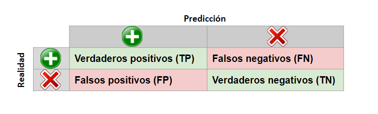

- **TP** es la cantidad de **positivos** que fueron clasificados correctamente como **positivos**
- **TN** es la cantidad de **negativos** que fueron clasificados correctamente como **negativos**
- **FN** es la cantidad de **positivos** que fueron clasificados incorrectamente como **negativos**
- **FP** es la cantidad de **negativos** que fueron clasificados incorrectamente como **positivos**

## Métricas de desempeño

### Exactitud (accuracy ):

En general, ¿Qué porcentaje se predijo correctamente?

$$accuracy = \frac{TP + TN}{TP + TN + FP + FN} = \frac{TP + TN}{TotalTuplas}$$

### Tasa de error (missclasification rate):

En general, ¿Qué porcentaje se predijo incorrectamente?

$$ErrorRate = \frac{FP + FN}{TP + TN + FP + FN} = \frac{FP + FN}{TotalTuplas} = 1 - accuracy$$

### Sensibilidad, exhaustividad, tasa de verdaderos positivos:

¿Qué porcentaje de instancias **positivas** se identificó correctamente?

**Traduccion al ingles:**

- Recall
- Sensitivity
- True positive rate (TPR)
  $$Sensitivity = \frac{TP}{TP + FN} = \frac{TP}{TotalPositivos}$$

### Especificidad, tasa de verdaderos negativos

¿Qué porcentaje de instancias **negativas** se identificó correctamente?

**Traduccion al ingles:**

- Specificity
- True negative rate (TNR)

$$Specificity = \frac{TN}{TN + FP} = \frac{TN}{TotalNegativos}$$

### Precisión

¿Qué porcentaje de instancias clasificadas **positivas** son realmente **positivas**?
$$Precision = \frac{TP}{TP + FP} = \frac{TP}{TotalClasificadosPositivos}$$

### Precisión negativa

¿Qué porcentaje de instancias clasificadas **negativas** son realmente **negativas**?
$$NegativePrecision = \frac{TN}{TN + FN} = \frac{TN}{TotalClasificadosNegativos}$$

### Tasa falsos positivos (FPR)

¿Qué porcentaje de instancias **negativas** el clasificador marcó como **positivo**?
$$FalsePositiveRate = \frac{FP}{FP + TN} = \frac{FP}{TotalNegativos}$$

### Tasa falsos negativos (FNR)

¿Qué porcentaje de instancias **positivas** el clasificador marcó como **negativas**?

$$FalseNegativeRate = \frac{FN}{FN + TP} = \frac{FN}{TotalPositivos}$$

Cargamos librerias que vamos a usar:

```r
library(ISLR)
library(MASS)
library(dplyr)
```

## Ejemplo: evualuando un modelo de clasificación:

```r
names(Default)
```

```
## [1] "default" "student" "balance" "income"
```

```r
summary(Default)
```

```
##  default    student       balance           income
##  No :9667   No :7056   Min.   :   0.0   Min.   :  772
##  Yes: 333   Yes:2944   1st Qu.: 481.7   1st Qu.:21340
##                        Median : 823.6   Median :34553
##                        Mean   : 835.4   Mean   :33517
##                        3rd Qu.:1166.3   3rd Qu.:43808
##                        Max.   :2654.3   Max.   :73554
```

### Creamos el dataset train y test

veamos cuantas tuplas tenemos:

```r
nrow(Default)
```

```
## [1] 10000
```

Elegimos los tamaños para el conjunto de entrenamiento y el conjunto de pruebas

```r
ntrain <- nrow(Default)*0.8
ntest <- nrow(Default)*0.2
c(ntrain,ntest)
```

```
## [1] 8000 2000
```

Creamos el los conjuntos de entrenamiento y de pruebas, elegimos aleatoriamente tuplas y las asignamos

```r
set.seed(161)
index_train<-sample(1:nrow(Default),size = ntrain)
train<-Default[index_train,]
test<-Default[-index_train,]
```

```r
summary(train)
```

```
##  default    student       balance           income
##  No :7749   No :5664   Min.   :   0.0   Min.   :  772
##  Yes: 251   Yes:2336   1st Qu.: 478.8   1st Qu.:21391
##                        Median : 819.1   Median :34677
##                        Mean   : 829.8   Mean   :33556
##                        3rd Qu.:1160.0   3rd Qu.:43782
##                        Max.   :2654.3   Max.   :73554
```

```r
summary(test)
```

```
##  default    student       balance           income
##  No :1918   No :1392   Min.   :   0.0   Min.   : 2541
##  Yes:  82   Yes: 608   1st Qu.: 493.2   1st Qu.:20955
##                        Median : 837.4   Median :33878
##                        Mean   : 857.5   Mean   :33362
##                        3rd Qu.:1193.3   3rd Qu.:43883
##                        Max.   :2578.5   Max.   :70701
```

## Entrenamiento

Creamos nuetro modelo con la funcion glm (logistico), intentamos predecir **default** con los atributos **balance**, **student**, e **income**.

```r
logit_reg <- glm(default~balance+student+income,data = train,family = "binomial")
```

## Pruebas

```r
predicted_value <- predict(logit_reg,test,type = "response")
predicted_class <- ifelse(predicted_value>0.5, "Yes","No")
performance_data<-data.frame(observed=test$default,
           predicted= predicted_class) # Creamos un dataframe, con los valores observados y predecidos
```

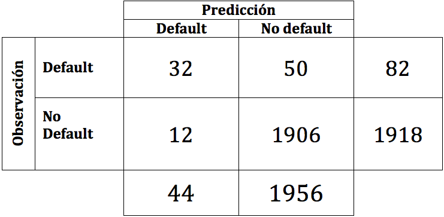

Calculamos los valores interiores de la matriz de confusion:

```
- **tp**: verdaderos positivos
- **tn**: verdaderos negativos
- **fp**: falsos positivos
- **fn**: falsos negativos
```

```r
tp<-sum(performance_data$observed=="Yes" & performance_data$predicted=="Yes")
tn<-sum(performance_data$observed=="No" & performance_data$predicted=="No")
fp<-sum(performance_data$observed=="No" & performance_data$predicted=="Yes")
fn<-sum(performance_data$observed=="Yes" & performance_data$predicted=="No")
data.frame(tp,tn,fp,fn)
```

| tp | tn | fp | fn |
| --- | --- | --- | --- |
| 32 | 1906 | 12 | 50 |

```r
positive <- sum(performance_data$observed=="Yes")
negative <- sum(performance_data$observed=="No")
predicted_positive <- sum(performance_data$predicted=="Yes")
predicted_negative <- sum(performance_data$predicted=="No")
total <- nrow(performance_data)
data.frame(positive, negative,predicted_positive,predicted_negative)
```

| positive | negative | predicted_positive | predicted_negative |
| --- | --- | --- | --- |
| 82 | 1918 | 44 | 1956 |

Ahora calculamos las metricas de desempeño

```r
accuracy <- (tp+tn)/total
error_rate <- (fp+fn)/total
sensitivity <- tp/positive
especificity <- tn/negative
precision <- tp/predicted_positive
npv <- tn / predicted_negative
data.frame(accuracy,error_rate,sensitivity,especificity,precision,npv)
```

| accuracy | error_rate | sensitivity | especificity | precision | npv |
| --- | --- | --- | --- | --- | --- |
| 0.969 | 0.031 | 0.3902439 | 0.9937435 | 0.7272727 | 0.9744376 |

## Desempeño con curva de ROC

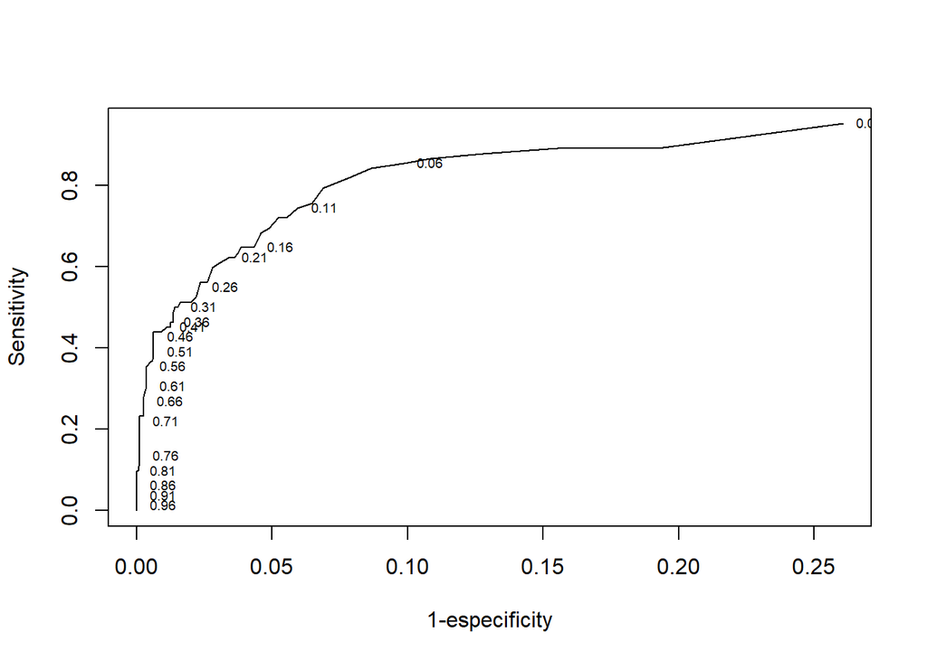

```r
roc_data <- function(model, test, step=0.01) {
  out<-data.frame()
  cut <- seq(step, 1, by = step)
  for (i in cut) {
  predicted_value <- predict(logit_reg, test, type = "response")
  predicted_class <- ifelse(predicted_value > i, "Yes", "No")
  performance_data <- data.frame(observed = test$default,predicted = predicted_class)
  predicted_positive <- sum(performance_data$predicted=="Yes")
  predicted_negative <- sum(performance_data$predicted=="No")
  positive <- sum(performance_data$observed == "Yes")
  negative <- sum(performance_data$observed == "No")
  total <- nrow(performance_data)
  tp <-sum(performance_data$observed == "Yes" &performance_data$predicted == "Yes")
  tn <-sum(performance_data$observed == "No" & performance_data$predicted == "No")
  fn<-sum(performance_data$observed=="Yes" & performance_data$predicted=="No")
  sensitivity <- tp / positive
  especificity <- tn / negative
  precision <- tp / predicted_positive
  npv <- tn / predicted_negative
  fpr <- fn/negative

  out<-rbind(out,c(i,1-especificity,sensitivity,especificity,precision,npv,fpr))
  }
  names(out)<-c("cut","1-Especificity","Sensivity","Especificity","Precision","npv","fpr")
  return(out)
}

roc_graph <- roc_data(logit_reg,test,step = 0.01)
plot(roc_graph$`1-Especificity`,roc_graph$Sensivity,xlab = "1-especificity", ylab = "Sensitivity",type = "l")
index<-seq(1,nrow(roc_graph), by=nrow(roc_graph)*0.05)
text(roc_graph$`1-Especificity`[index],roc_graph$Sensivity[index], labels = roc_graph$cut[index], cex=0.6, pos=4)
```

La curva de ROC nos proporciona una medida de desempeño de nuestro clasificador, entre mas cercana el area bajo la curva de ROC sea a 1, mejor es nuestro clasificador.

```r
library(ROCR)
```

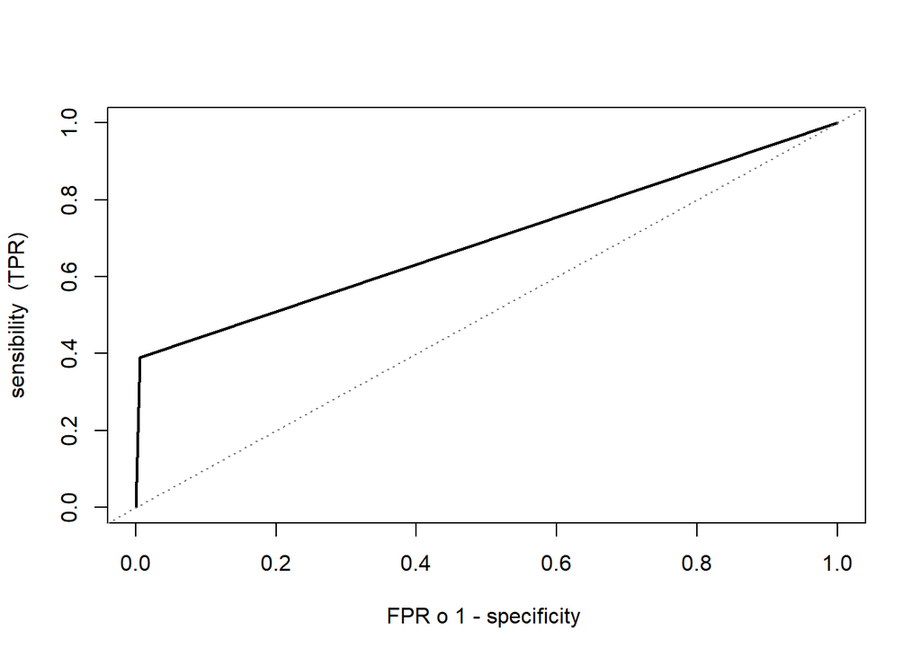

```r
pred_values <- as.numeric(ifelse(predicted_class=="Yes", 1, 0))
obs_values <-   as.numeric(ifelse(test$default=="Yes", 1, 0))

roc_pred <- prediction(pred_values, obs_values)
perf <-performance(roc_pred, measure="tpr", x.measure="fpr")

plot(perf, lwd=2, xlab="FPR o 1 - specificity ",
 ylab="sensibility  (TPR)")

abline(a=0, b=1, col="gray50", lty=3) #Dibujamos la diagonal
```

```r
perf
```

```
## An object of class "performance"
## Slot "x.name":
## [1] "False positive rate"
##
## Slot "y.name":
## [1] "True positive rate"
##
## Slot "alpha.name":
## [1] "Cutoff"
##
## Slot "x.values":
## [[1]]
## [1] 0.000000000 0.006256517 1.000000000
##
##
## Slot "y.values":
## [[1]]
## [1] 0.0000000 0.3902439 1.0000000
##
##
## Slot "alpha.values":
## [[1]]
## [1] Inf   1   0
```

Como podemos ver el cutoff queda en x = 0.006256517, y = 0.3902439

## AUC - Area bajo la curva ROC

```r
auc <- performance(roc_pred, "auc")
auc <- unlist(slot(auc, "y.values"))
auc
```

```
## [1] 0.6919937
```

**Referencia:** https://rpubs.com/chzelada/275494